# DMahoney_FinalPart2

Delia Mahoney

12/10/2021

# Final Project

## Questions 1-4

### Q1

The relationship between body mass and length seems generally linear through the bulk of the data, but slightly curved at either extreme.

### Q2

The histogram for body mass is close to a normal distribution, but not exact. The histogram for body length is even further from normal, with a steep increase and several outlying values at the high end of the range.

### Q3

The shapiro tests conclude that the data is not from a normal distribution because both p-values are so low we reject the null hypothesis that the data is from normal. Because of this and the shapes of the histograms, I do believe that the unconditioned data is not normally distributed.

### Q4

The conditional boxplots show that for both species, males tend to be heavier, and overall penguins from the D.dorsalis species tend to be heavier. However, males in the D.sublineatus had more of a range in weight than any other category.

```r
require("here")
delomys = read.csv(here("data", "delomys.csv"))
delomys_df = data.frame(delomys)

summary(delomys_df$body_mass)
```

```
##    Min. 1st Qu.  Median    Mean 3rd Qu.    Max.
##    5.00   35.00   43.00   44.06   54.00  105.00
```

```r
summary(delomys_df$body_length)
```

```
##    Min. 1st Qu.  Median    Mean 3rd Qu.    Max.
##    49.0   106.0   116.0   114.7   124.0   265.0
```

```r
shapiro.test(delomys_df$body_mass)
```

```
##
##  Shapiro-Wilk normality test
##
## data:  delomys_df$body_mass
## W = 0.99506, p-value = 4.33e-05
```

```r
shapiro.test(delomys_df$body_length)
```

```
##
##  Shapiro-Wilk normality test
##
## data:  delomys_df$body_length
## W = 0.87609, p-value < 2.2e-16
```

body mass and length are not from a normally distributed population

### PLOTS

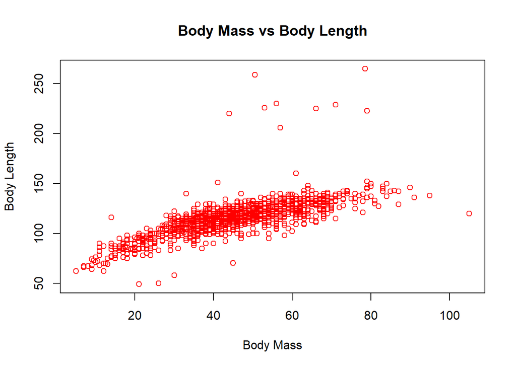

```r
plot(delomys_df$body_mass, delomys_df$body_length, col = "red", main = "Body Mass vs Body Length", xlab = "Body Mass", ylab = "Body Length")
```

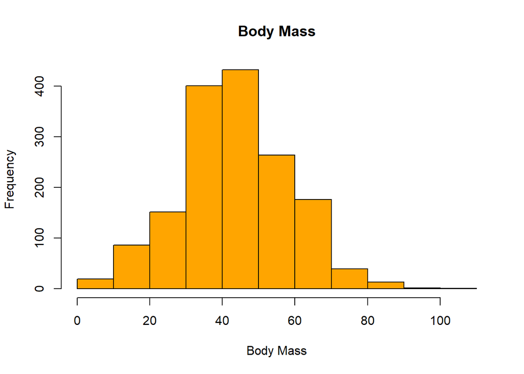

```r
hist(delomys_df$body_mass, col = "orange", main = "Body Mass", xlab = "Body Mass", ylab = "Frequency")
```

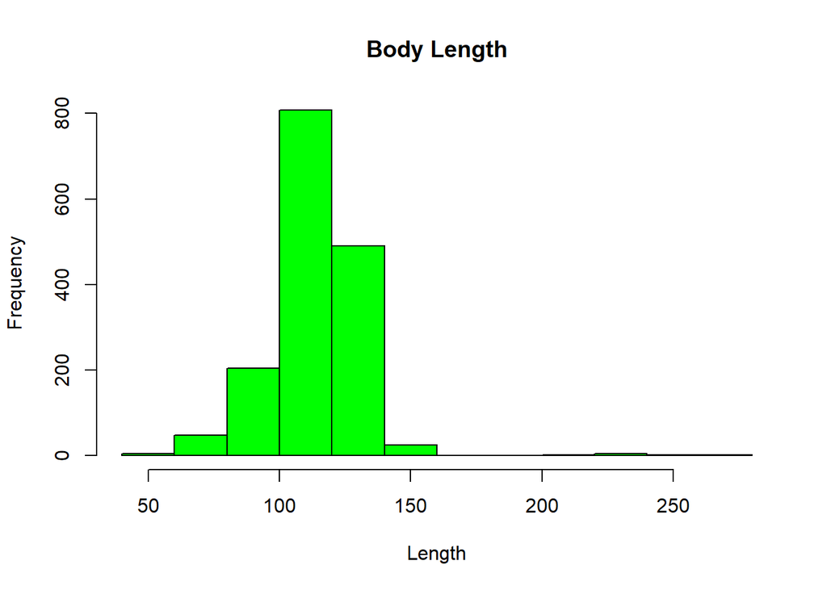

```r
hist(delomys_df$body_length, col = "green", main = "Body Length", xlab = "Length", ylab = "Frequency")
```

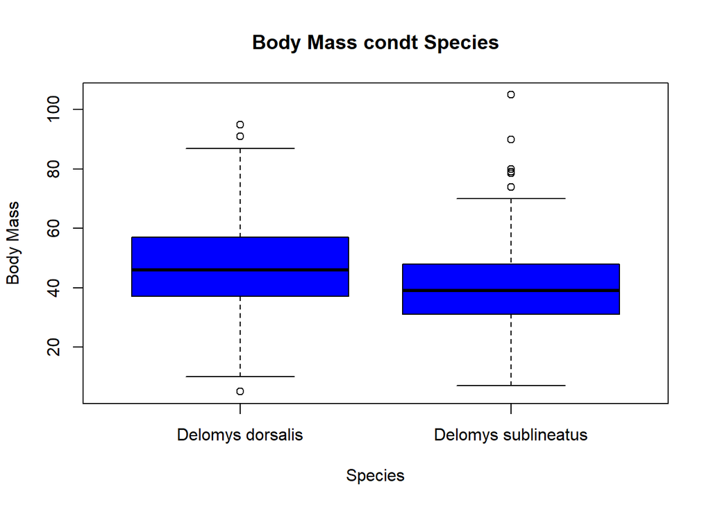

```r
boxplot(body_mass ~ binomial, data = delomys_df, col = "blue", main = "Body Mass condt Species", xlab = "Species", ylab = "Body Mass")
```

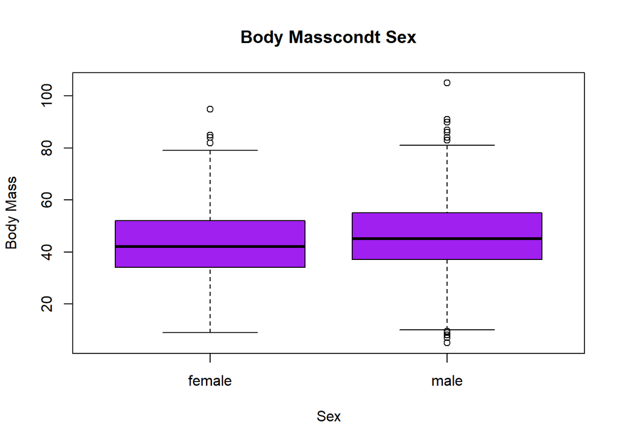

```r
boxplot(body_mass ~ sex, data = delomys_df, col = "purple", main = "Body Masscondt Sex", xlab = "Sex", ylab = "Body Mass")
```

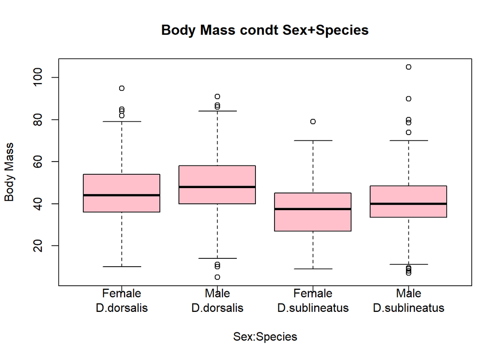

```r
boxplot(body_mass ~ sex:binomial, data = delomys_df, col= "pink", main = "Body Mass condt Sex+Species", xlab = "Sex:Species", names = c("Female\nD.dorsalis", "Male\nD.dorsalis", "Female\nD.sublineatus", "Male\nD.sublineatus"), ylab = "Body Mass")
```

## Questions 5-6

### Q5

Given the results of the shapiro tests and histograms, we reject the null hypothesis that the residuals are drawn from a normally distributed population

### Q6

The violations of the normality assumption are not equally severe in all cases, fit1 is the most in violation with the lowest p-value and least normally shaped histogram. Fits 2-5 are pretty similar in histogram shape but with slight varying p-values, fit 2 is the least “in violation” with the largest p values.

### MODELS

```r
fit1 = lm(body_length ~ body_mass, data = delomys_df)
fit1
```

```
##
## Call:
## lm(formula = body_length ~ body_mass, data = delomys_df)
##
## Coefficients:
## (Intercept)    body_mass
##     76.1247       0.8755
```

```r
fit2 = lm(body_mass ~ sex, data = delomys_df)
anova(fit2)
```

```
## Analysis of Variance Table
##
## Response: body_mass
##             Df Sum Sq Mean Sq F value    Pr(>F)
## sex          1   3062 3061.68  13.943 0.0001951 ***
## Residuals 1578 346507  219.59
## ---
## Signif. codes:  0 '***' 0.001 '**' 0.01 '*' 0.05 '.' 0.1 ' ' 1
```

```r
fit3 = lm(body_mass ~ binomial, data = delomys_df)
anova(fit3)
```

```
## Analysis of Variance Table
##
## Response: body_mass
##             Df Sum Sq Mean Sq F value    Pr(>F)
## binomial     1  21290 21289.7  102.08 < 2.2e-16 ***
## Residuals 1583 330164   208.6
## ---
## Signif. codes:  0 '***' 0.001 '**' 0.01 '*' 0.05 '.' 0.1 ' ' 1
```

```r
fit4 = lm(body_mass ~ sex + binomial, data = delomys_df)
anova(fit4)
```

```
## Analysis of Variance Table
##
## Response: body_mass
##             Df Sum Sq Mean Sq F value    Pr(>F)
## sex          1   3062  3061.7  14.958 0.0001144 ***
## binomial     1  23727 23727.1 115.923 < 2.2e-16 ***
## Residuals 1577 322780   204.7
## ---
## Signif. codes:  0 '***' 0.001 '**' 0.01 '*' 0.05 '.' 0.1 ' ' 1
```

```r
fit5 = lm(body_mass ~ sex * binomial, data = delomys_df)
anova(fit5)
```

```
## Analysis of Variance Table
##
## Response: body_mass
##                Df Sum Sq Mean Sq  F value    Pr(>F)
## sex             1   3062  3061.7  14.9489  0.000115 ***
## binomial        1  23727 23727.1 115.8500 < 2.2e-16 ***
## sex:binomial    1      1     0.8   0.0039  0.950442
## Residuals    1576 322779   204.8
## ---
## Signif. codes:  0 '***' 0.001 '**' 0.01 '*' 0.05 '.' 0.1 ' ' 1
```

### RESIDUALS

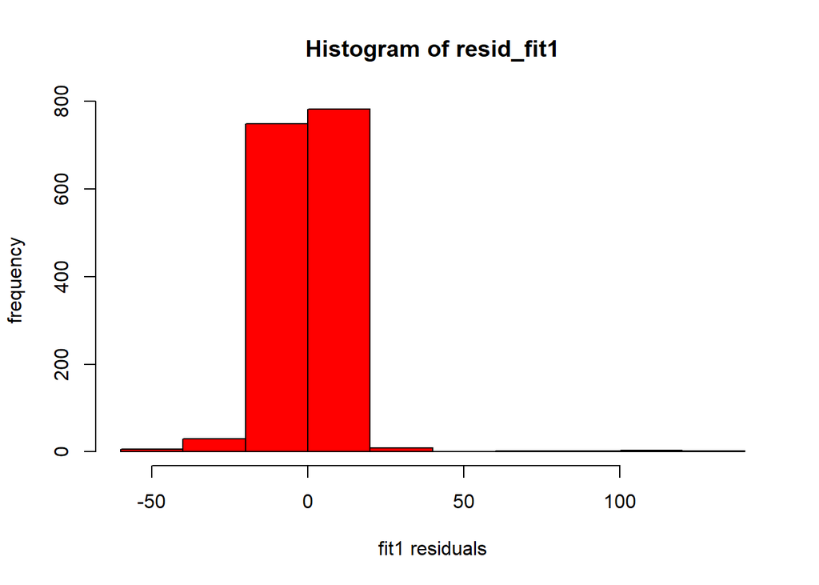

```r
resid_fit1 = residuals(fit1)
hist(resid_fit1, col = "red", xlab = "fit1 residuals", ylab = "frequency")
```

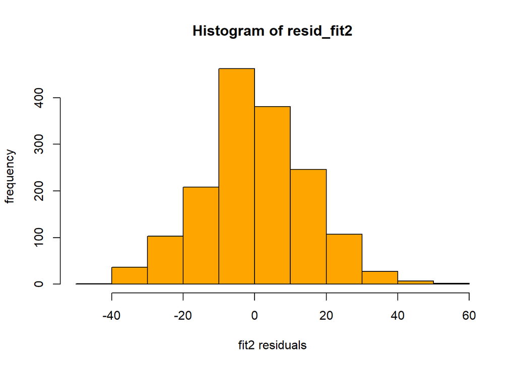

```r
resid_fit2 = residuals(fit2)
hist(resid_fit2, col = "orange", xlab = "fit2 residuals", ylab = "frequency")
```

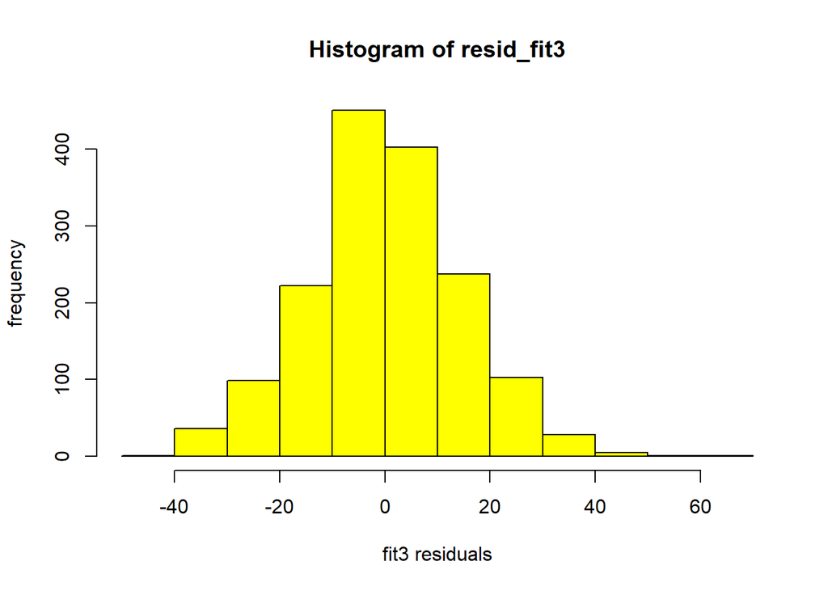

```r
resid_fit3 = residuals(fit3)
hist(resid_fit3, col = "yellow", xlab = "fit3 residuals", ylab = "frequency")
```

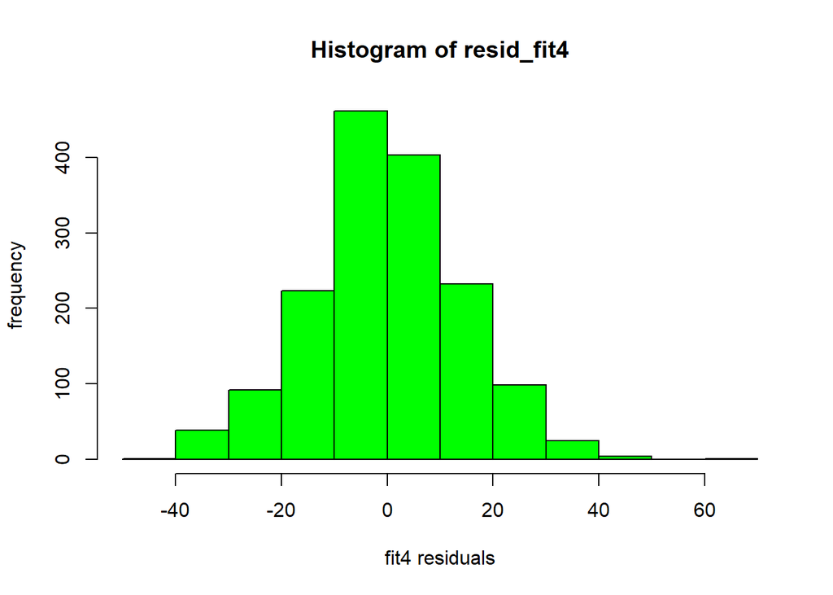

```r
resid_fit4 = residuals(fit4)
hist(resid_fit4, col = "green", xlab = "fit4 residuals", ylab = "frequency")
```

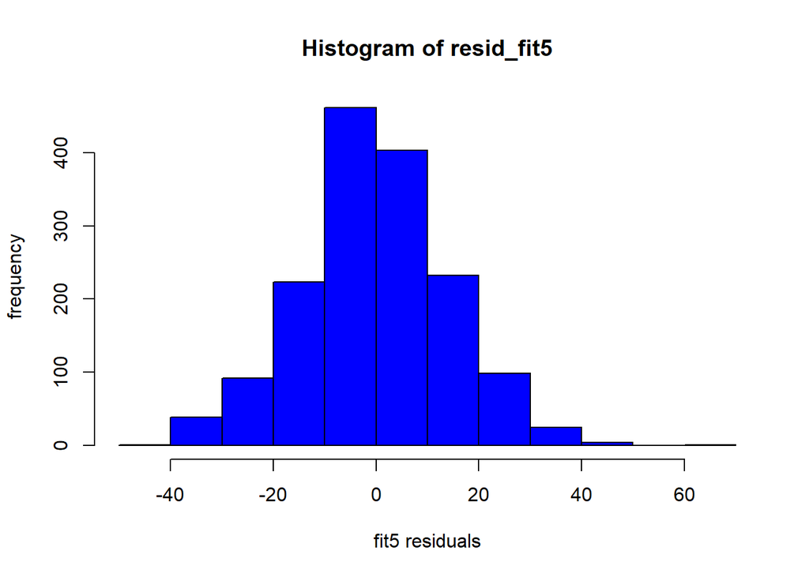

```r
resid_fit5 = residuals(fit5)
hist(resid_fit5, col = "blue", xlab = "fit5 residuals", ylab = "frequency")
```

### SHAPIRO TESTS

```r
shapiro.test(resid_fit1)
```

```
##
##  Shapiro-Wilk normality test
##
## data:  resid_fit1
## W = 0.73462, p-value < 2.2e-16
```

```r
shapiro.test(resid_fit2)
```

```
##
##  Shapiro-Wilk normality test
##
## data:  resid_fit2
## W = 0.99563, p-value = 0.0001541
```

```r
shapiro.test(resid_fit3)
```

```
##
##  Shapiro-Wilk normality test
##
## data:  resid_fit3
## W = 0.99535, p-value = 8.103e-05
```

```r
shapiro.test(resid_fit4)
```

```
##
##  Shapiro-Wilk normality test
##
## data:  resid_fit4
## W = 0.99525, p-value = 6.805e-05
```

```r
shapiro.test(resid_fit5)
```

```
##
##  Shapiro-Wilk normality test
##
## data:  resid_fit5
## W = 0.99526, p-value = 6.816e-05
```

Reject null, p-values all less than .05

## Questions 7-9

### Q7

The magnitude of the relationship between body length and body mass is .875, the slope of body mass from the model coefficient table.

### Q9

The expected body length of an animal with a weight of 0g is 76.124, the intercept value for body length.

```r
knitr::kable(coef(summary(fit1)))
```

|  | Estimate | Std. Error | t value | Pr(>\|t\|) |
| --- | --- | --- | --- | --- |
| (Intercept) | 76.1246565 | 0.9158120 | 83.12258 | 0 |
| body_mass | 0.8754988 | 0.0196905 | 44.46298 | 0 |

## Questions 10-13

### Q10

The base case for sex is female.

### Q11

The base case for binomial(species) is D.dorsalis.

### Q12

Male animals are heavier.

### Q13

D.dorsalis animals are heavier.

### COEFFICIENT TABLES

```r
knitr::kable(coef(summary(fit2)))
```

|  | Estimate | Std. Error | t value | Pr(>\|t\|) |
| --- | --- | --- | --- | --- |
| (Intercept) | 42.711465 | 0.5288929 | 80.756355 | 0.0000000 |
| sexmale | 2.784133 | 0.7456117 | 3.734024 | 0.0001951 |

```r
knitr::kable(coef(summary(fit3)))
```

|  | Estimate | Std. Error | t value | Pr(>\|t\|) |
| --- | --- | --- | --- | --- |
| (Intercept) | 46.752427 | 0.4499933 | 103.89582 | 0 |
| binomialDelomys sublineatus | -7.683058 | 0.7604562 | -10.10322 | 0 |

```r
knitr::kable(coef(summary(fit4)))
```

|  | Estimate | Std. Error | t value | Pr(>\|t\|) |
| --- | --- | --- | --- | --- |
| (Intercept) | 45.070355 | 0.5556429 | 81.113891 | 0e+00 |
| sexmale | 3.795395 | 0.7259609 | 5.228099 | 2e-07 |
| binomialDelomys sublineatus | -8.193492 | 0.7609985 | -10.766764 | 0e+00 |

```r
knitr::kable(coef(summary(fit5)))
```

|  | Estimate | Std. Error | t value | Pr(>\|t\|) |
| --- | --- | --- | --- | --- |
| (Intercept) | 45.0554562 | 0.6052973 | 74.4352459 | 0.0000000 |
| sexmale | 3.8280908 | 0.8966667 | 4.2692460 | 0.0000208 |
| binomialDelomys sublineatus | -8.1417394 | 1.1281046 | -7.2171847 | 0.0000000 |
| sexmale:binomialDelomys sublineatus | -0.0950187 | 1.5285856 | -0.0621612 | 0.9504424 |

## Questions 14-16

### Q15

The interaction of sex:binomial is not significant because the p-value for the interaction term is .95 which is much greater than the significance level of .05.

### Q16

The p-values of the sex effect generally decreased from the individual model to either of the combined models, indicating it became a more significant predictor for the additive and interactive models. The p-value change from the sex-single-predictor model to the additive model was -0.00008, and from additive to interactive was +.0000006. The effect of species remained pretty much the same across the board, but always with a very small p-value (0) indicating it has a very high significance.

### ANOVA TABLES

```r
knitr::kable(anova(fit2))
```

|  | Df | Sum Sq | Mean Sq | F value | Pr(>F) |
| --- | --- | --- | --- | --- | --- |
| sex | 1 | 3061.678 | 3061.6779 | 13.94294 | 0.0001951 |
| Residuals | 1578 | 346507.131 | 219.5863 | NA | NA |

```r
knitr::kable(anova(fit3))
```

|  | Df | Sum Sq | Mean Sq | F value | Pr(>F) |
| --- | --- | --- | --- | --- | --- |
| binomial | 1 | 21289.68 | 21289.6805 | 102.0751 | 0 |
| Residuals | 1583 | 330164.45 | 208.5688 | NA | NA |

```r
knitr::kable(anova(fit4))
```

|  | Df | Sum Sq | Mean Sq | F value | Pr(>F) |
| --- | --- | --- | --- | --- | --- |
| sex | 1 | 3061.678 | 3061.6779 | 14.95838 | 0.0001144 |
| binomial | 1 | 23727.134 | 23727.1342 | 115.92320 | 0.0000000 |
| Residuals | 1577 | 322779.997 | 204.6798 | NA | NA |

```r
knitr::kable(anova(fit5))
```

|  | Df | Sum Sq | Mean Sq | F value | Pr(>F) |
| --- | --- | --- | --- | --- | --- |
| sex | 1 | 3.061678e+03 | 3.061678e+03 | 14.948932 | 0.0001150 |
| binomial | 1 | 2.372713e+04 | 2.372713e+04 | 115.849977 | 0.0000000 |
| sex:binomial | 1 | 7.913846e-01 | 7.913846e-01 | 0.003864 | 0.9504424 |
| Residuals | 1576 | 3.227792e+05 | 2.048091e+02 | NA | NA |

## Questions 17-18

### Q17

The additive (fit4) and interactive (fit5) models have the lowest AIC values

### Q18

I would select the additive model (fit4) as the best fit. It has the lowest AIC value and very low p-values in the ANOVA table. The additive model is also more complex than the single-predictor model, but without being overly complex. It is easier to comprehend as a model because it doesn’t have the interaction term that the interactive model has which can be weird to interpret.

```r
AIC(fit2)
```

```
## [1] 13006.8
```

```r
AIC(fit3)
```

```
## [1] 12966.36
```

```r
AIC(fit4)
```

```
## [1] 12896.73
```

```r
AIC(fit5)
```

```
## [1] 12898.72
```